# Reproducible Research: Peer Assessment 1

## Loading and preprocessing the data

The following code allows to download data from the repository, but the chunk is set to eval=FALSE, in order to avoid downloading each time the markdown is knitted.

```r
download.file("https://d396qusza40orc.cloudfront.net/repdata%2Fdata%2Factivity.zip", destfile="data_activity.zip", method="curl")
unzip("data_activity.zip")
```

### 1. Load the data

Importing data into R.

```r
activity <- read.csv("activity.csv")
```

### 2. Process/transform the data

Formatting dates variable as date.

```r
activity$date <- as.Date(
  activity$date,
  "%Y-%m-%d")
```

## What is mean total number of steps taken per day?

### 1. Calculate the total number of steps taken per day

We calculate the total steps taken each day, grouping activity by date and summing up the steps in each interval for each day.

```r
library(dplyr)
daily_steps <- activity %>%
  group_by(date) %>%
  summarise(total_steps = sum(steps,
                              na.rm=TRUE
                              )
            )
```

### 2. Make a histogram of the total number of steps taken each day

Now we can generate and show the histogram.

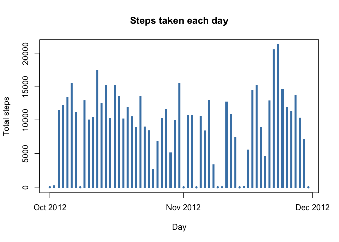

```r
plot(x = daily_steps$date,
     y = daily_steps$total_steps,
     type = "h",
     col = "steelblue",
     lwd = 4,
     lend = "square",
     main = "Steps taken each day",
     xlab = "Day",
     ylab = "Total steps",
     xaxt = "n"
)
dates_to_label <- seq(min(daily_steps$date), max(daily_steps$date+1), by = "1 month")
axis.Date(1, at = dates_to_label, format = "%b %Y")
```

### 3. Calculate and report the mean and median of the total number of steps taken per day

The mean and median of the total number of steps taken for day is calculated as follows.

```r
avg_dsteps <- activity %>%
  group_by(date) %>%
  summarise(mean_steps = mean(steps,
                              na.rm=TRUE
                              ),
            median_steps = median(steps,
                                  na.rm=TRUE
                                  )
            ) %>%
  ungroup()
names(avg_dsteps) <- c("Date",
                       "Mean steps",
                       "Median steps"
                       )
```

We now report the mean and median total number of steps taken for each day.

```r
knitr::kable(avg_dsteps)
```

| Date | Mean steps | Median steps |
| --- | --- | --- |
| 2012-10-01 | NaN | NA |
| 2012-10-02 | 0.4375000 | 0 |
| 2012-10-03 | 39.4166667 | 0 |
| 2012-10-04 | 42.0694444 | 0 |
| 2012-10-05 | 46.1597222 | 0 |
| 2012-10-06 | 53.5416667 | 0 |
| 2012-10-07 | 38.2465278 | 0 |
| 2012-10-08 | NaN | NA |
| 2012-10-09 | 44.4826389 | 0 |
| 2012-10-10 | 34.3750000 | 0 |
| 2012-10-11 | 35.7777778 | 0 |
| 2012-10-12 | 60.3541667 | 0 |
| 2012-10-13 | 43.1458333 | 0 |
| 2012-10-14 | 52.4236111 | 0 |
| 2012-10-15 | 35.2048611 | 0 |
| 2012-10-16 | 52.3750000 | 0 |
| 2012-10-17 | 46.7083333 | 0 |
| 2012-10-18 | 34.9166667 | 0 |
| 2012-10-19 | 41.0729167 | 0 |
| 2012-10-20 | 36.0937500 | 0 |
| 2012-10-21 | 30.6284722 | 0 |
| 2012-10-22 | 46.7361111 | 0 |
| 2012-10-23 | 30.9652778 | 0 |
| 2012-10-24 | 29.0104167 | 0 |
| 2012-10-25 | 8.6527778 | 0 |
| 2012-10-26 | 23.5347222 | 0 |
| 2012-10-27 | 35.1354167 | 0 |
| 2012-10-28 | 39.7847222 | 0 |
| 2012-10-29 | 17.4236111 | 0 |
| 2012-10-30 | 34.0937500 | 0 |
| 2012-10-31 | 53.5208333 | 0 |
| 2012-11-01 | NaN | NA |
| 2012-11-02 | 36.8055556 | 0 |
| 2012-11-03 | 36.7048611 | 0 |
| 2012-11-04 | NaN | NA |
| 2012-11-05 | 36.2465278 | 0 |
| 2012-11-06 | 28.9375000 | 0 |
| 2012-11-07 | 44.7326389 | 0 |
| 2012-11-08 | 11.1770833 | 0 |
| 2012-11-09 | NaN | NA |
| 2012-11-10 | NaN | NA |
| 2012-11-11 | 43.7777778 | 0 |
| 2012-11-12 | 37.3784722 | 0 |
| 2012-11-13 | 25.4722222 | 0 |
| 2012-11-14 | NaN | NA |
| 2012-11-15 | 0.1423611 | 0 |
| 2012-11-16 | 18.8923611 | 0 |
| 2012-11-17 | 49.7881944 | 0 |
| 2012-11-18 | 52.4652778 | 0 |
| 2012-11-19 | 30.6979167 | 0 |
| 2012-11-20 | 15.5277778 | 0 |
| 2012-11-21 | 44.3993056 | 0 |
| 2012-11-22 | 70.9270833 | 0 |
| 2012-11-23 | 73.5902778 | 0 |
| 2012-11-24 | 50.2708333 | 0 |
| 2012-11-25 | 41.0902778 | 0 |
| 2012-11-26 | 38.7569444 | 0 |
| 2012-11-27 | 47.3819444 | 0 |
| 2012-11-28 | 35.3576389 | 0 |
| 2012-11-29 | 24.4687500 | 0 |
| 2012-11-30 | NaN | NA |

## What is the average daily activity pattern?

### 1. Make a time series plot of the 5-minute interval and the average number of steps taken, averaged across all days

First, we create the dataset of the average number of steps taken for each 5-minute interval, across all days.

```r
 daily_pattern <- activity %>%
  group_by(interval) %>%
  summarise(average_steps = mean(steps,
                                na.rm=TRUE
                                )
            )
```

Plotting data.

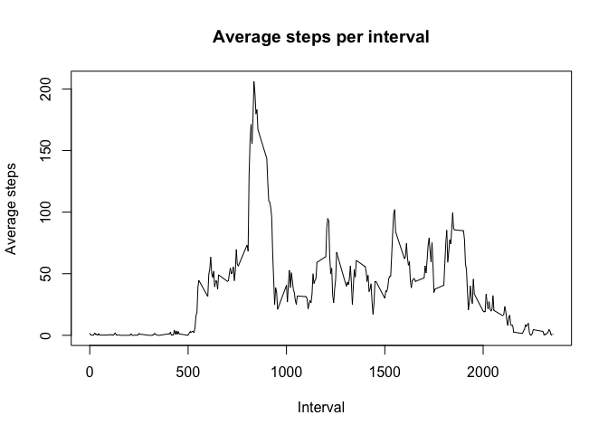

```r
plot(daily_pattern$interval,
     daily_pattern$average_steps,
     type = "l",
     main = "Average steps per interval",
     xlab="Interval",
     ylab= "Average steps"
     )
```

### 2. Which 5-minute interval, on average across all the days in the dataset, contains the maximum number of steps?

Calculating the interval which contains the maximum number of steps.

```r
daily_pattern$interval[[which.max(daily_pattern$average_steps)]]
```

```
## [1] 835
```

## Imputing missing values

### 1. Calculate and report the total number of missing values in the dataset

The following chunk calculates the total number of rows with missing values in activity dataset.

```r
rows_with_na <- activity[!complete.cases(activity), ]
nrow(rows_with_na)
```

```
## [1] 2304
```

### 2. Devise a strategy for filling in all of the missing values in the dataset

The strategy devised is to fill missing values of steps taken with the average steps of the same interval across all days. We now calculate the new column and put it in a new numeric vector, called filled_steps. Whenever the steps for a given interval are present, we just copy such value into filled_steps corrispondent value.

```r
filled_steps <- numeric(length=nrow(activity))
for (i in 1:nrow(activity)) {
  if(is.na(activity$steps[[i]])) {
    empty_interval <- activity$interval[[i]]
    filled_steps[[i]] <- daily_pattern$average_steps[[which(daily_pattern$interval==empty_interval)]]
  }
  else filled_steps[[i]] <- activity$steps[[i]]
  }
```

### 3. Create a new dataset that is equal to the original dataset but with the missing data filled in.

Since we already created the new column, i.e. “filled_steps, in the previous paragraph, we now just have to create the new dataset as a copy of”activity” and then substitute the steps column with filled_steps.

```r
activity_filled <- activity
activity_filled$steps <- filled_steps
```

### 4. Make a histogram of the total number of steps taken each day and Calculate and report the mean and median total number of steps taken per day.

First, we calculate the total steps taken each day (as in the first assignment, but starting from activity_filled instead of activity.

```r
library(dplyr)
daily_steps_filled <- activity_filled %>%
  group_by(date) %>%
  summarise(total_steps = sum(steps))
```

Now we can generate and show the histogram.

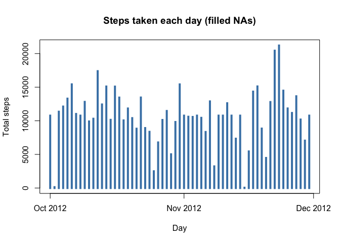

```r
plot(x = daily_steps_filled$date,
     y = daily_steps_filled$total_steps,
     type = "h",
     col = "steelblue",
     lwd = 4,
     lend = "square",
     main = "Steps taken each day (filled NAs)",
     xlab = "Day",
     ylab = "Total steps",
     xaxt = "n"
)
dates_to_label <- seq(min(daily_steps_filled$date), max(daily_steps_filled$date+1), by = "1 month")
axis.Date(1, at = dates_to_label, format = "%b %Y")
```

The mean and median of the total number of steps taken for day is calculated again as in the first assignment, again starting with activity_filled instead of activity.

```r
avg_dsteps_filled <- activity_filled %>%
  group_by(date) %>%
  summarise(mean_steps_f = mean(steps),
            median_steps_f = median(steps)
            ) %>%
  ungroup()
names(avg_dsteps_filled) <- c("Date",
                              "Mean steps (filled NAs)",
                              "Median steps (filled NAs)")
```

We now merge the two datasets of mean and median steps per day and report them, in order to be able to evaluate the differences.

```r
names(daily_steps) <- c("Date", "Total steps")
names(daily_steps_filled) <- c("Date", "Total steps (filled NAs)")
dsteps_compare_temp1 <- merge(daily_steps,
                            daily_steps_filled,
                            by="Date"
                            )
dsteps_compare_temp2 <- merge(avg_dsteps,
                            avg_dsteps_filled,
                            by="Date"
                            )
dsteps_compare <- merge(dsteps_compare_temp1,
                        dsteps_compare_temp2,
                            by="Date"
                            )
dsteps_compare <- dsteps_compare %>%
  relocate( "Mean steps (filled NAs)",
            .after = "Mean steps"
            )
knitr::kable(dsteps_compare)
```

| Date | Total steps | Total steps (filled NAs) | Mean steps | Mean steps (filled NAs) | Median steps | Median steps (filled NAs) |
| --- | --- | --- | --- | --- | --- | --- |
| 2012-10-01 | 0 | 10766.19 | NaN | 37.3825996 | NA | 34.11321 |
| 2012-10-02 | 126 | 126.00 | 0.4375000 | 0.4375000 | 0 | 0.00000 |
| 2012-10-03 | 11352 | 11352.00 | 39.4166667 | 39.4166667 | 0 | 0.00000 |
| 2012-10-04 | 12116 | 12116.00 | 42.0694444 | 42.0694444 | 0 | 0.00000 |
| 2012-10-05 | 13294 | 13294.00 | 46.1597222 | 46.1597222 | 0 | 0.00000 |
| 2012-10-06 | 15420 | 15420.00 | 53.5416667 | 53.5416667 | 0 | 0.00000 |
| 2012-10-07 | 11015 | 11015.00 | 38.2465278 | 38.2465278 | 0 | 0.00000 |
| 2012-10-08 | 0 | 10766.19 | NaN | 37.3825996 | NA | 34.11321 |
| 2012-10-09 | 12811 | 12811.00 | 44.4826389 | 44.4826389 | 0 | 0.00000 |
| 2012-10-10 | 9900 | 9900.00 | 34.3750000 | 34.3750000 | 0 | 0.00000 |
| 2012-10-11 | 10304 | 10304.00 | 35.7777778 | 35.7777778 | 0 | 0.00000 |
| 2012-10-12 | 17382 | 17382.00 | 60.3541667 | 60.3541667 | 0 | 0.00000 |
| 2012-10-13 | 12426 | 12426.00 | 43.1458333 | 43.1458333 | 0 | 0.00000 |
| 2012-10-14 | 15098 | 15098.00 | 52.4236111 | 52.4236111 | 0 | 0.00000 |
| 2012-10-15 | 10139 | 10139.00 | 35.2048611 | 35.2048611 | 0 | 0.00000 |
| 2012-10-16 | 15084 | 15084.00 | 52.3750000 | 52.3750000 | 0 | 0.00000 |
| 2012-10-17 | 13452 | 13452.00 | 46.7083333 | 46.7083333 | 0 | 0.00000 |
| 2012-10-18 | 10056 | 10056.00 | 34.9166667 | 34.9166667 | 0 | 0.00000 |
| 2012-10-19 | 11829 | 11829.00 | 41.0729167 | 41.0729167 | 0 | 0.00000 |
| 2012-10-20 | 10395 | 10395.00 | 36.0937500 | 36.0937500 | 0 | 0.00000 |
| 2012-10-21 | 8821 | 8821.00 | 30.6284722 | 30.6284722 | 0 | 0.00000 |
| 2012-10-22 | 13460 | 13460.00 | 46.7361111 | 46.7361111 | 0 | 0.00000 |
| 2012-10-23 | 8918 | 8918.00 | 30.9652778 | 30.9652778 | 0 | 0.00000 |
| 2012-10-24 | 8355 | 8355.00 | 29.0104167 | 29.0104167 | 0 | 0.00000 |
| 2012-10-25 | 2492 | 2492.00 | 8.6527778 | 8.6527778 | 0 | 0.00000 |
| 2012-10-26 | 6778 | 6778.00 | 23.5347222 | 23.5347222 | 0 | 0.00000 |
| 2012-10-27 | 10119 | 10119.00 | 35.1354167 | 35.1354167 | 0 | 0.00000 |
| 2012-10-28 | 11458 | 11458.00 | 39.7847222 | 39.7847222 | 0 | 0.00000 |
| 2012-10-29 | 5018 | 5018.00 | 17.4236111 | 17.4236111 | 0 | 0.00000 |
| 2012-10-30 | 9819 | 9819.00 | 34.0937500 | 34.0937500 | 0 | 0.00000 |
| 2012-10-31 | 15414 | 15414.00 | 53.5208333 | 53.5208333 | 0 | 0.00000 |
| 2012-11-01 | 0 | 10766.19 | NaN | 37.3825996 | NA | 34.11321 |
| 2012-11-02 | 10600 | 10600.00 | 36.8055556 | 36.8055556 | 0 | 0.00000 |
| 2012-11-03 | 10571 | 10571.00 | 36.7048611 | 36.7048611 | 0 | 0.00000 |
| 2012-11-04 | 0 | 10766.19 | NaN | 37.3825996 | NA | 34.11321 |
| 2012-11-05 | 10439 | 10439.00 | 36.2465278 | 36.2465278 | 0 | 0.00000 |
| 2012-11-06 | 8334 | 8334.00 | 28.9375000 | 28.9375000 | 0 | 0.00000 |
| 2012-11-07 | 12883 | 12883.00 | 44.7326389 | 44.7326389 | 0 | 0.00000 |
| 2012-11-08 | 3219 | 3219.00 | 11.1770833 | 11.1770833 | 0 | 0.00000 |
| 2012-11-09 | 0 | 10766.19 | NaN | 37.3825996 | NA | 34.11321 |
| 2012-11-10 | 0 | 10766.19 | NaN | 37.3825996 | NA | 34.11321 |
| 2012-11-11 | 12608 | 12608.00 | 43.7777778 | 43.7777778 | 0 | 0.00000 |
| 2012-11-12 | 10765 | 10765.00 | 37.3784722 | 37.3784722 | 0 | 0.00000 |
| 2012-11-13 | 7336 | 7336.00 | 25.4722222 | 25.4722222 | 0 | 0.00000 |
| 2012-11-14 | 0 | 10766.19 | NaN | 37.3825996 | NA | 34.11321 |
| 2012-11-15 | 41 | 41.00 | 0.1423611 | 0.1423611 | 0 | 0.00000 |
| 2012-11-16 | 5441 | 5441.00 | 18.8923611 | 18.8923611 | 0 | 0.00000 |
| 2012-11-17 | 14339 | 14339.00 | 49.7881944 | 49.7881944 | 0 | 0.00000 |
| 2012-11-18 | 15110 | 15110.00 | 52.4652778 | 52.4652778 | 0 | 0.00000 |
| 2012-11-19 | 8841 | 8841.00 | 30.6979167 | 30.6979167 | 0 | 0.00000 |
| 2012-11-20 | 4472 | 4472.00 | 15.5277778 | 15.5277778 | 0 | 0.00000 |
| 2012-11-21 | 12787 | 12787.00 | 44.3993056 | 44.3993056 | 0 | 0.00000 |
| 2012-11-22 | 20427 | 20427.00 | 70.9270833 | 70.9270833 | 0 | 0.00000 |
| 2012-11-23 | 21194 | 21194.00 | 73.5902778 | 73.5902778 | 0 | 0.00000 |
| 2012-11-24 | 14478 | 14478.00 | 50.2708333 | 50.2708333 | 0 | 0.00000 |
| 2012-11-25 | 11834 | 11834.00 | 41.0902778 | 41.0902778 | 0 | 0.00000 |
| 2012-11-26 | 11162 | 11162.00 | 38.7569444 | 38.7569444 | 0 | 0.00000 |
| 2012-11-27 | 13646 | 13646.00 | 47.3819444 | 47.3819444 | 0 | 0.00000 |
| 2012-11-28 | 10183 | 10183.00 | 35.3576389 | 35.3576389 | 0 | 0.00000 |
| 2012-11-29 | 7047 | 7047.00 | 24.4687500 | 24.4687500 | 0 | 0.00000 |
| 2012-11-30 | 0 | 10766.19 | NaN | 37.3825996 | NA | 34.11321 |

We can see that the effect of filling is that estimate values after filling NAs are always valid values, without NAs or NaNs. The total number of steps per day is also affected.

## Are there differences in activity patterns between weekdays and weekends?

### 1. Create a new factor variable in the dataset with two levels – “weekday” and “weekend”

We now add a column to activity_filled, indicating if the date is a weekday or weekend day.

```r
library(lubridate)
activity_filled <- activity_filled %>%
  mutate(
    day_of_week_num = wday(date, week_start = 1),
    day_type = case_when(
      day_of_week_num %in% c(6, 7) ~ "Weekend",
      TRUE ~ "Weekday"
    ),
    day_type = factor(day_type, levels = c("Weekday", "Weekend"))
  ) %>%
  select(-day_of_week_num)
```

### 2. Make a panel plot containing a time series plot of the 5-minute interval and the average number of steps taken, averaged across all weekday days or weekend days

First, we create the dataset of the average number of steps taken for each 5-minute interval, separating weekdays and weekend days.

```r
 daily_pattern_w <- activity_filled %>%
  group_by(interval,day_type) %>%
  summarise(average_steps = mean(steps,
                                na.rm=TRUE
                                )
            )
```

Plotting data.

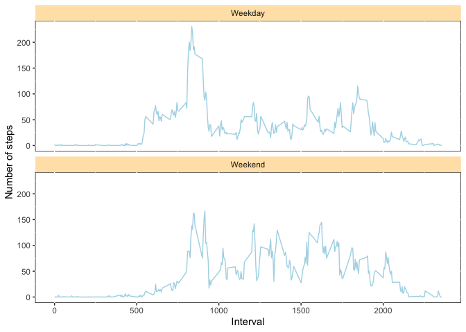

```r
library(ggplot2)
plotweek <- ggplot(daily_pattern_w,
       aes(
         x=interval,
         y=average_steps
         )
       ) +
  geom_line(colour = "lightblue")+
  facet_wrap(daily_pattern_w$day_type,
                 nrow=2,
                 ncol=1
             )  +
  labs(
    x = "Interval",
    y = "Number of steps"
  ) +
  theme(
    panel.background = element_rect(
      fill = NA,
      colour = "black"
      ),
    strip.background = element_rect(fill = "#FFE4B5")
    )
print(plotweek)
```